# TSF TASK 3 - GRIP MARCH'21

# Exploratory Data Analysis - Retail

### Objective:-

- Perform ‘Exploratory Data Analysis’ on dataset ‘SampleSuperstore'
- As a business manager, try to find out the weak areas where you can work to make more profit.
- What all business problems you can derive by exploring the data?

Ques. What is EDA ? Ans. In statistics, exploratory data analysis is an approach to analyzing data sets to summarize their main characteristics, often using statistical graphics and other data visualization methods. A statistical model can be used or not, but primarily EDA is for seeing what the data can tell us beyond the formal modeling or hypothesis testing task.

```python
# importing libraries
import numpy as np
import pandas as pd
import matplotlib.pyplot as plt
%matplotlib inline
import seaborn as sns
import warnings
warnings.filterwarnings('ignore')
```

```python
# Reading dataset
data=pd.read_csv("SampleSuperstore.csv")
data
```

|  | Ship Mode | Segment | Country | City | State | Postal Code | Region | Category | Sub-Category | Sales | Quantity | Discount | Profit |
| --- | --- | --- | --- | --- | --- | --- | --- | --- | --- | --- | --- | --- | --- |
| 0 | Second Class | Consumer | United States | Henderson | Kentucky | 42420 | South | Furniture | Bookcases | 261.9600 | 2 | 0.00 | 41.9136 |
| 1 | Second Class | Consumer | United States | Henderson | Kentucky | 42420 | South | Furniture | Chairs | 731.9400 | 3 | 0.00 | 219.5820 |
| 2 | Second Class | Corporate | United States | Los Angeles | California | 90036 | West | Office Supplies | Labels | 14.6200 | 2 | 0.00 | 6.8714 |
| 3 | Standard Class | Consumer | United States | Fort Lauderdale | Florida | 33311 | South | Furniture | Tables | 957.5775 | 5 | 0.45 | -383.0310 |
| 4 | Standard Class | Consumer | United States | Fort Lauderdale | Florida | 33311 | South | Office Supplies | Storage | 22.3680 | 2 | 0.20 | 2.5164 |
| ... | ... | ... | ... | ... | ... | ... | ... | ... | ... | ... | ... | ... | ... |
| 9989 | Second Class | Consumer | United States | Miami | Florida | 33180 | South | Furniture | Furnishings | 25.2480 | 3 | 0.20 | 4.1028 |
| 9990 | Standard Class | Consumer | United States | Costa Mesa | California | 92627 | West | Furniture | Furnishings | 91.9600 | 2 | 0.00 | 15.6332 |
| 9991 | Standard Class | Consumer | United States | Costa Mesa | California | 92627 | West | Technology | Phones | 258.5760 | 2 | 0.20 | 19.3932 |
| 9992 | Standard Class | Consumer | United States | Costa Mesa | California | 92627 | West | Office Supplies | Paper | 29.6000 | 4 | 0.00 | 13.3200 |
| 9993 | Second Class | Consumer | United States | Westminster | California | 92683 | West | Office Supplies | Appliances | 243.1600 | 2 | 0.00 | 72.9480 |

9994 rows × 13 columns

```python
# Checking for rows and coloumns
data.shape
```

```
(9994, 13)
```

```python
# describing the dataset in summarized way
data.describe()
```

|  | Postal Code | Sales | Quantity | Discount | Profit |
| --- | --- | --- | --- | --- | --- |
| count | 9994.000000 | 9994.000000 | 9994.000000 | 9994.000000 | 9994.000000 |
| mean | 55190.379428 | 229.858001 | 3.789574 | 0.156203 | 28.656896 |
| std | 32063.693350 | 623.245101 | 2.225110 | 0.206452 | 234.260108 |
| min | 1040.000000 | 0.444000 | 1.000000 | 0.000000 | -6599.978000 |
| 25% | 23223.000000 | 17.280000 | 2.000000 | 0.000000 | 1.728750 |
| 50% | 56430.500000 | 54.490000 | 3.000000 | 0.200000 | 8.666500 |
| 75% | 90008.000000 | 209.940000 | 5.000000 | 0.200000 | 29.364000 |
| max | 99301.000000 | 22638.480000 | 14.000000 | 0.800000 | 8399.976000 |

```python
# More information about dataset
data.info()
```

```
<class 'pandas.core.frame.DataFrame'>
RangeIndex: 9994 entries, 0 to 9993
Data columns (total 13 columns):
 #   Column        Non-Null Count  Dtype
---  ------        --------------  -----
 0   Ship Mode     9994 non-null   object
 1   Segment       9994 non-null   object
 2   Country       9994 non-null   object
 3   City          9994 non-null   object
 4   State         9994 non-null   object
 5   Postal Code   9994 non-null   int64
 6   Region        9994 non-null   object
 7   Category      9994 non-null   object
 8   Sub-Category  9994 non-null   object
 9   Sales         9994 non-null   float64
 10  Quantity      9994 non-null   int64
 11  Discount      9994 non-null   float64
 12  Profit        9994 non-null   float64
dtypes: float64(3), int64(2), object(8)
memory usage: 1015.1+ KB
```

```python
# Checking for null values in our dataset
data.isnull().sum()
```

```
Ship Mode       0
Segment         0
Country         0
City            0
State           0
Postal Code     0
Region          0
Category        0
Sub-Category    0
Sales           0
Quantity        0
Discount        0
Profit          0
dtype: int64
```

```python
# Listing all coloumns in our dataset
data.columns
```

```
Index(['Ship Mode', 'Segment', 'Country', 'City', 'State', 'Postal Code',
       'Region', 'Category', 'Sub-Category', 'Sales', 'Quantity', 'Discount',
       'Profit'],
      dtype='object')
```

```python
# Checking for duplicate values in our dataset
data.duplicated().sum()
```

```
17
```

```python
# Removing all the duplicate values
data.drop_duplicates(keep=False,inplace=True)
```

```python
data.shape
```

```
(9960, 13)
```

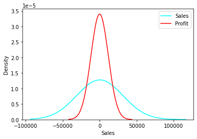

```python
#EDA
sns.kdeplot(data['Sales'],color='cyan',label='Sales',bw=50)
sns.kdeplot(data['Profit'],color='red',label='Profit',bw=50)
plt.legend()
```

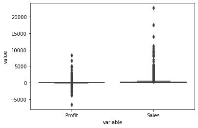

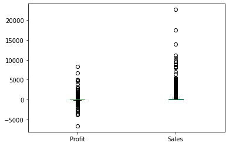

```python
# Finding Outliers
df = pd.DataFrame(data = data, columns = ['Profit','Sales'])
sns.boxplot(x="variable", y="value", data=pd.melt(df))
df.plot(kind='box')
```

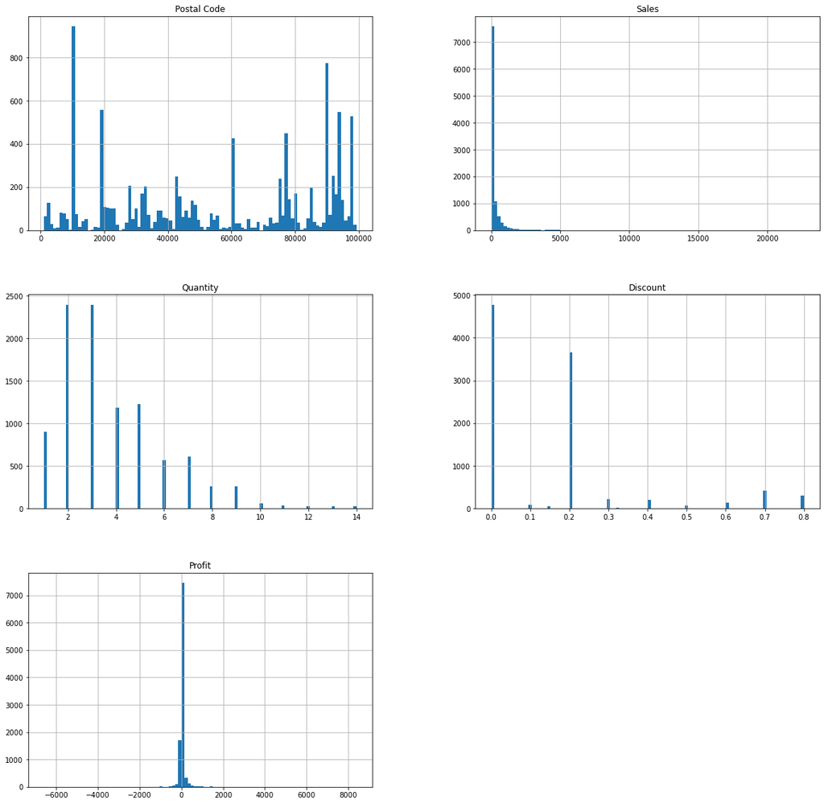

```python
# Visualising data by plotting histograms
data.hist(bins=100,figsize=(20,20))
plt.show()
```

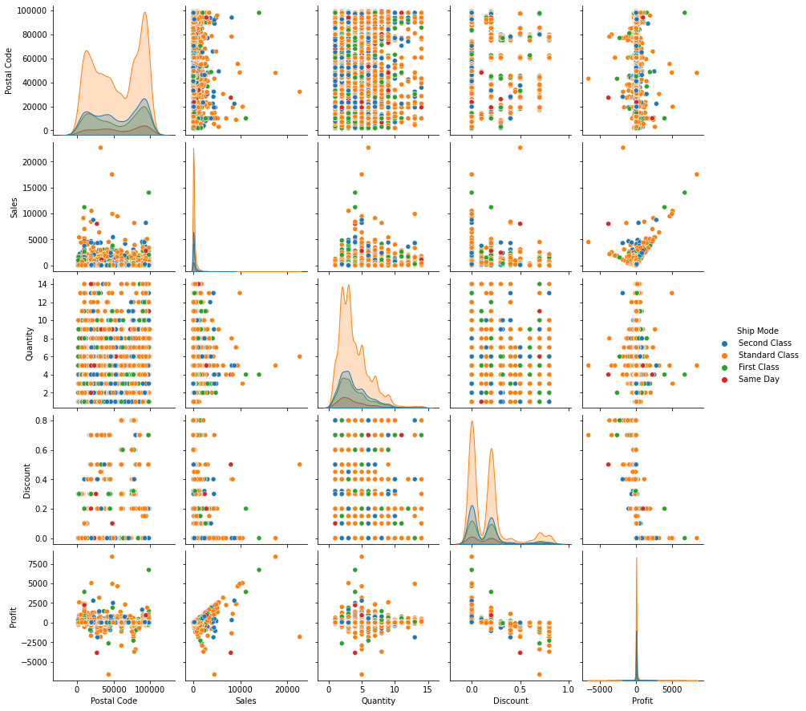

```python
# Analysing the data based on Ship Mode
sns.pairplot(data,hue="Ship Mode")
```

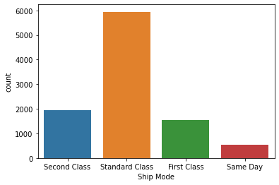

```python
# Analysing the data based on Ship Mode
sns.countplot(x='Ship Mode',data=data)
```

Conclusion:- The preffered ship mode is Standard Class.

```
array([<AxesSubplot:ylabel='Profit'>, <AxesSubplot:ylabel='Discount'>,
       <AxesSubplot:ylabel='Sales'>], dtype=object)
```

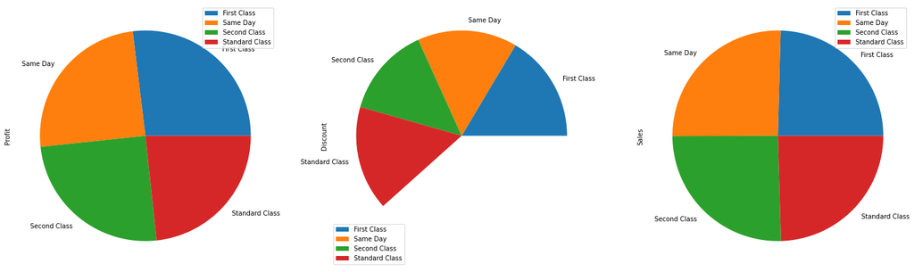

```python
# Analysing the data based on Ship Mode
dataf=data.groupby(['Ship Mode'])[['Profit','Discount','Sales']].mean()
dataf.plot.pie(subplots=True,figsize=(25,25),labels=dataf.index)
```

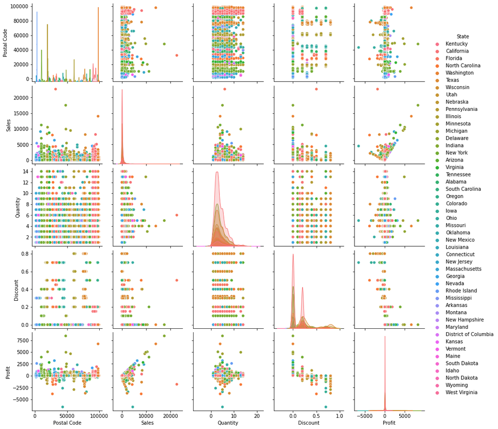

```python
# Analysing the data based on State data
sns.pairplot(data,hue='State')
```

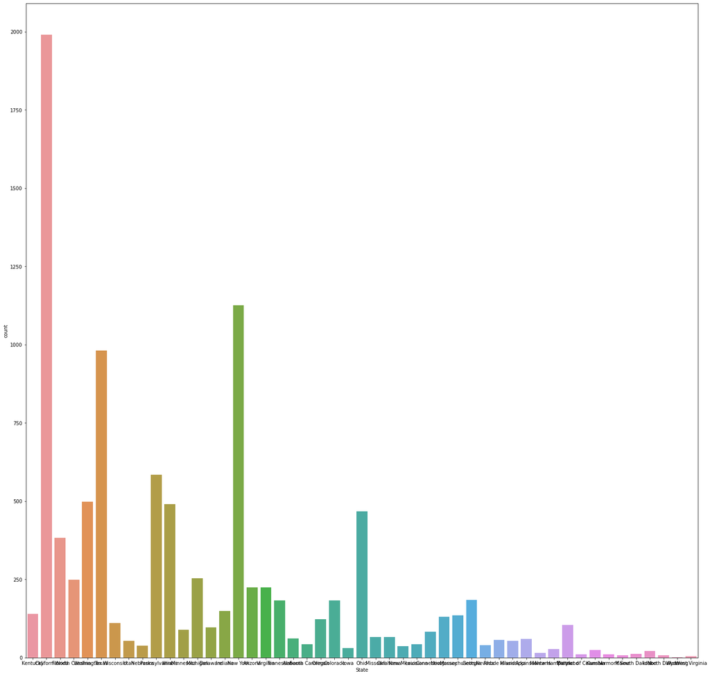

```python
# Analysing the data based on State data
plt.figure(figsize=(25,25))
sns.countplot(x='State',data=data)
plt.show()
```

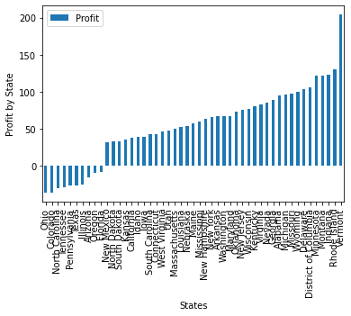

```python
# Analysing the data based on Profit in each State
dataf1=data.groupby(['State'])[['Profit','Discount','Sales']].mean()
dataf11=dataf1.sort_values('Profit')
dataf11[['Profit']].plot(kind='bar')
plt.xlabel('States')
plt.ylabel('Profit by State')
plt.show()
```

Conclusion:- The highest profit is in Vermont State.

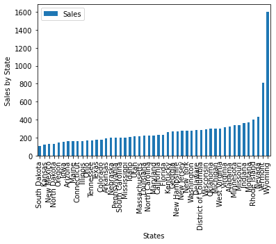

```python
# Analysing the data based on Sale in each State
dataf12=dataf1.sort_values('Sales')
dataf12[['Sales']].plot(kind='bar')
plt.xlabel('States')
plt.ylabel('Sales by State')
plt.show()
```

Conclusion:- The highest sales is in Wyoming State.

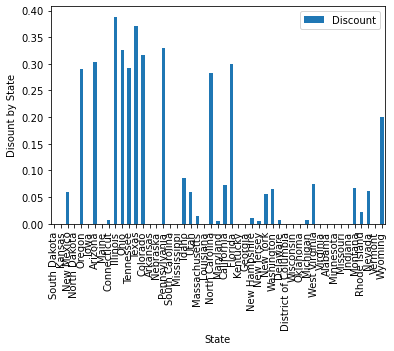

```python
# Analysing the data based on Discount in each State
dataf13=dataf1.sort_values('Discount')
dataf12[['Discount']].plot(kind='bar')
plt.xlabel('State')
plt.ylabel('Disount by State')
plt.show()
```

Conclusion:- The highest discount is in Illinois State.

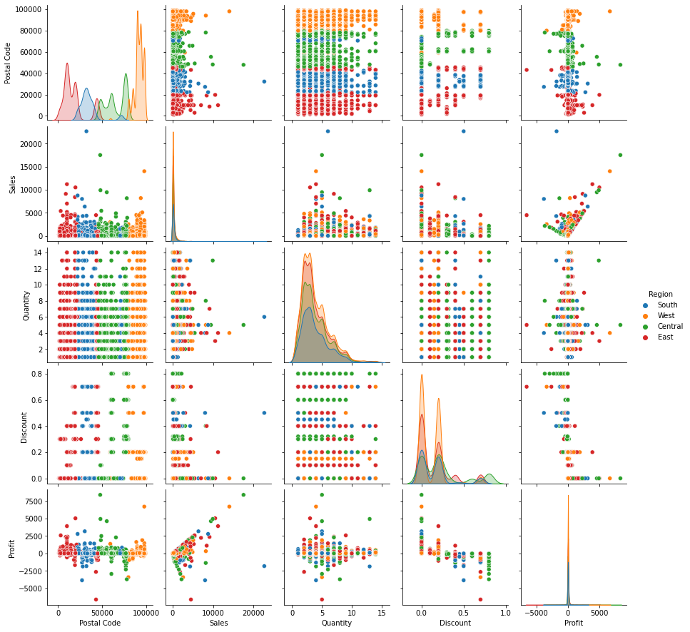

```python
# Analysing the data based on Region data
sns.pairplot(data,hue='Region')
```

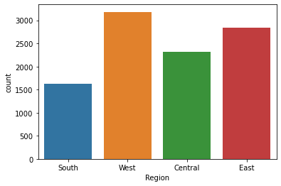

```python
# Analysing the data based on Region data
sns.countplot(x='Region',data=data)
plt.show()
```

Conclusion:- The West has highest number of dealings.

```
array([<AxesSubplot:ylabel='Profit'>, <AxesSubplot:ylabel='Discount'>,
       <AxesSubplot:ylabel='Sales'>], dtype=object)
```

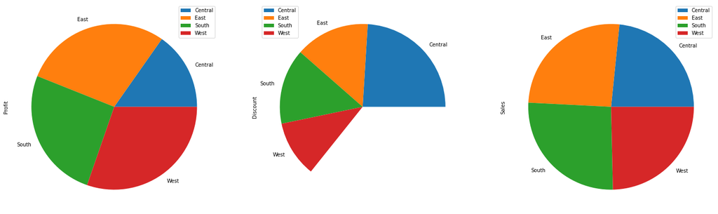

```python
# Analysing the data based on Region
dataf2=data.groupby(['Region'])[['Profit','Discount','Sales']].mean()
dataf2.plot.pie(subplots=True,figsize=(25,25),labels=dataf2.index)
```

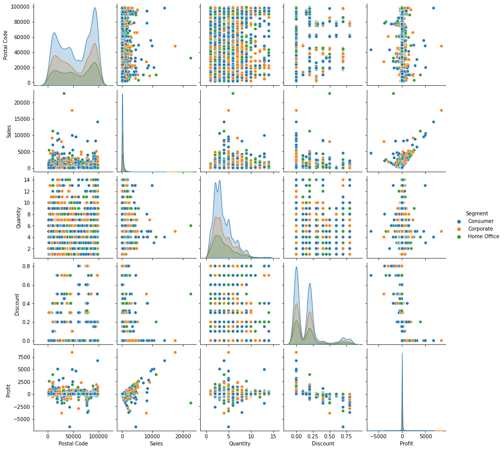

```python
# Analysing the data based on Segment data
sns.pairplot(data,hue='Segment')
```

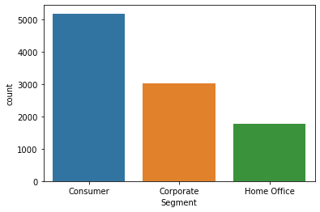

```python
# Analysing the data based on Segment data
sns.countplot(x='Segment',data=data)
plt.show()
```

Conclusion:- THe segment which buys more product lie in Consumer section.

```
array([<AxesSubplot:ylabel='Profit'>, <AxesSubplot:ylabel='Discount'>,
       <AxesSubplot:ylabel='Sales'>], dtype=object)
```

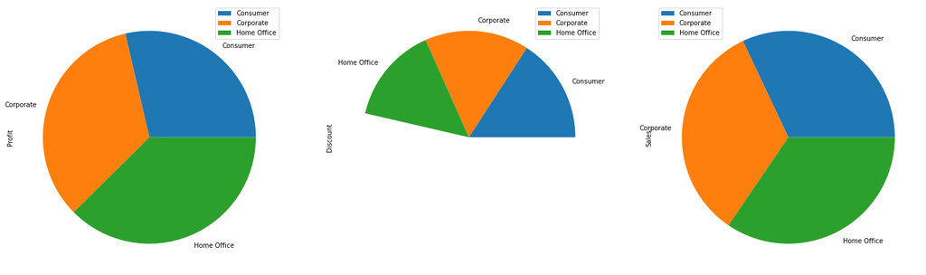

```python
# Analysing the data based on Segment
dataf3=data.groupby(['Segment'])[['Profit','Discount','Sales']].mean()
dataf3.plot.pie(subplots=True,figsize=(25,25),labels=dataf3.index)
```

Conclusion:- Profit is highest in home-office as well as sales are also highest here.

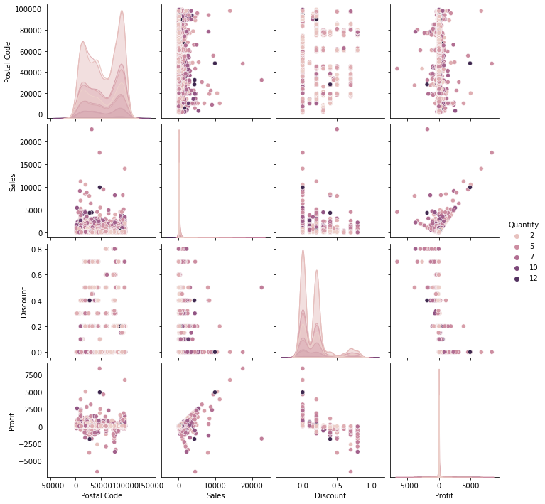

```python
# Analysing the data based on Quantity data
sns.pairplot(data,hue='Quantity')
```

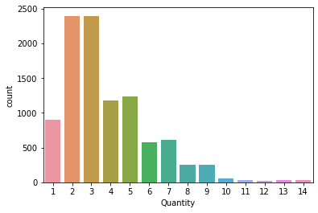

```python
# Analysing the data based on Quantity data
sns.countplot(x='Quantity',data=data)
plt.show()
```

```
array([<AxesSubplot:ylabel='Profit'>, <AxesSubplot:ylabel='Discount'>,
       <AxesSubplot:ylabel='Sales'>], dtype=object)
```

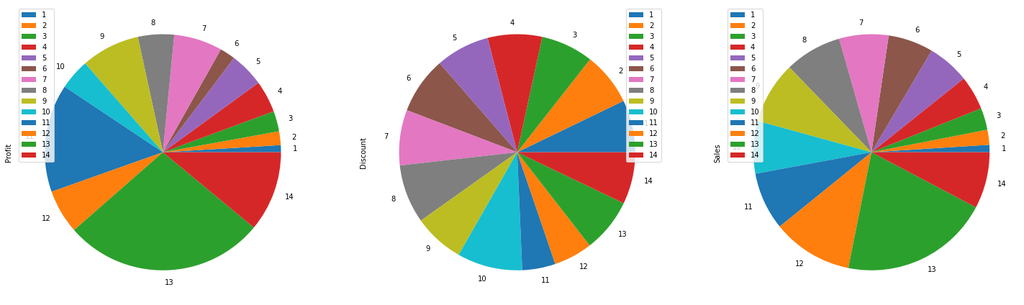

```python
# Analysing the data based on Quantity
dataf4=data.groupby(['Quantity'])[['Profit','Discount','Sales']].mean()
dataf4.plot.pie(subplots=True,figsize=(25,25))
```

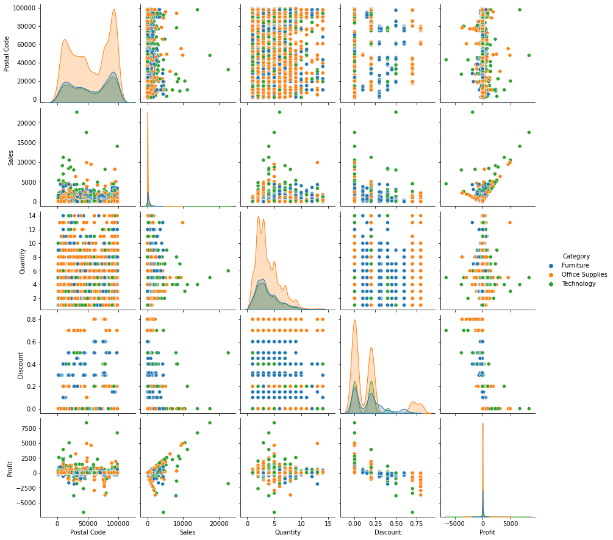

```python
# Analysing the data based on Category data
sns.pairplot(data,hue='Category')
```

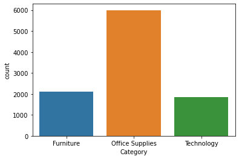

```python
# Analysing the data based on Category data
sns.countplot(x='Category',data=data)
plt.show()
```

Conclusion:- Office Supplies are more compared to furniture and technology.

```
array([<AxesSubplot:ylabel='Profit'>, <AxesSubplot:ylabel='Discount'>,
       <AxesSubplot:ylabel='Sales'>], dtype=object)
```

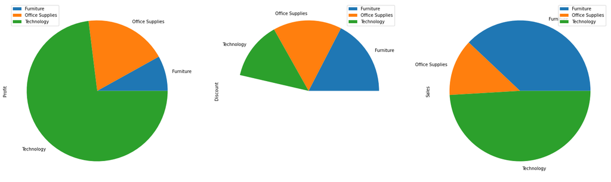

```python
# Analysing the data based on Category
dataf5=data.groupby(['Category'])[['Profit','Discount','Sales']].mean()
dataf5.plot.pie(subplots=True,figsize=(25,25),labels=dataf5.index)
```

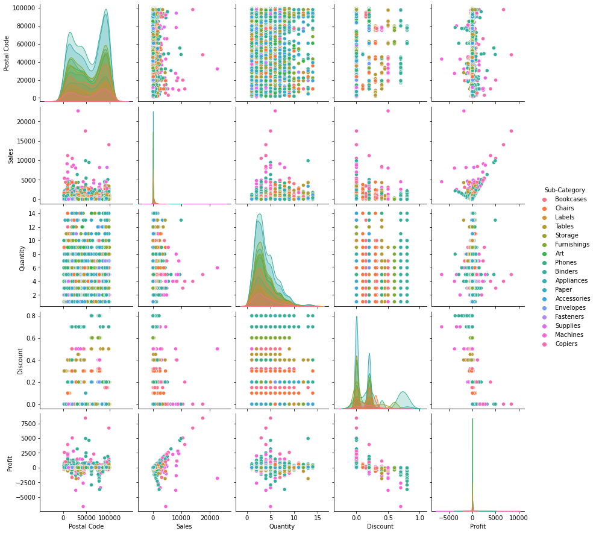

```python
# Analysing the data based on Sub-Category data
sns.pairplot(data,hue='Sub-Category')
```

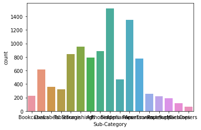

```python
# Analysing the data based on Sub-Category data
sns.countplot(x='Sub-Category',data=data)
plt.show()
```